# SARS-CoV-2 phylogeny visualization — concepts and gallery

What you can do with a tree, a metadata table, and ggtree

Author

Instructor notes

```r
library(ape)
library(treeio)
library(ggtree)
library(ggtreeExtra)
library(ggplot2)
library(ggnewscale)
library(dplyr)
library(tidyr)
library(readr)
library(lubridate)
library(patchwork)
library(Biostrings)
```

# Why this document exists

This is a gallery of the visualization techniques you will use in the SARS-CoV-2 project. Every concept is illustrated with a plot generated from the actual project data (`data/ncov_subsample.nwk` + `data/ncov_metadata.tsv`). Read it once before starting the analysis to see *what the destination looks like*; come back to it when you forget which `gheatmap` argument controls the gap between tree and matrix.

# 1. A phylogenetic tree is a 2-D coordinate system

This is the single most important idea in the project.

A drawn tree has two axes:

- The **y-axis** indexes tips. Internal y-coordinates are the average of the children’s y-coordinates. The order is determined by `ladderize()` and is otherwise arbitrary.
- The **x-axis** carries either **substitutions per site** (the raw output of a tree-builder) or **calendar time** (the output of a clock-calibration step). For SARS-CoV-2 builds, it is calendar time.

Once you accept this, *anything else you draw* is just another layer on the same coordinate system: tip points at `(x_tip, y_tip)`, heatmap cells at `(x_offset + col_index, y_tip)`, map labels connected from `(x_tip, y_tip)` to a real-world `(longitude, latitude)`.

```r
tree <- read.tree("data/ncov_subsample.nwk")
meta <- read_tsv("data/ncov_metadata.tsv", show_col_types = FALSE)

cat("Tips:", length(tree$tip.label), "\n")
```

```
Tips: 400
```

```r
cat("Branch units (max root-to-tip):",
    round(max(node.depth.edgelength(tree)), 2), " — should be a few years\n")
```

```
Branch units (max root-to-tip): 6.32  — should be a few years
```

```r
cat("Date span:", as.character(min(meta$date)), "→",
    as.character(max(meta$date)), "\n")
```

```
Date span: 2020-01-10 → 2026-04-10
```

## 1a. Branch length units — verify before you plot

`ggtree(td, mrsd = ...)` only works if branches are in **time** (years). If they are in substitutions/site, the time axis labels will be wrong and silently misleading.

```r
# Time-calibrated tree: a multi-year SARS-CoV-2 tree should have
# max(node.depth.edgelength()) on the order of 3–6 years.
# A subs/site tree would give ~0.001–0.01.
max(node.depth.edgelength(tree))
```

```
[1] 6.316
```

## 1b. The base time-axis tree

Every figure in this gallery is built on top of this single object. **`mrsd`** is the most recent sampling date — `ggtree` subtracts branch lengths from this anchor to place every internal node on the calendar.

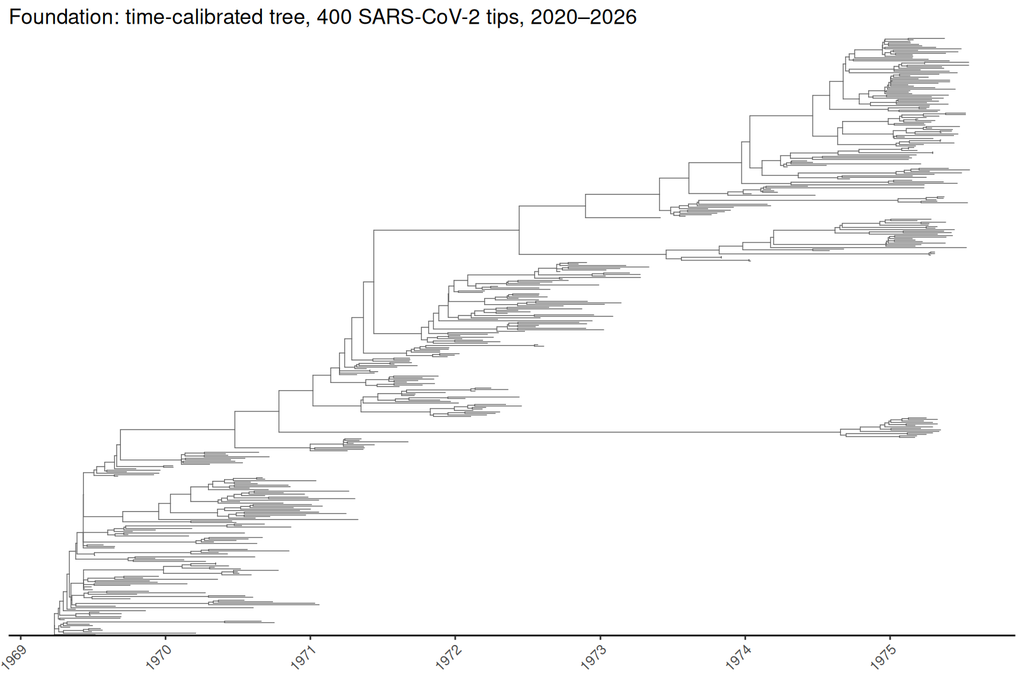

```r
meta <- meta %>%
  mutate(decimal_date = decimal_date(ymd(date)))

td <- full_join(as_tibble(tree), meta, by = c("label" = "strain")) %>%
  as.treedata()

mrsd_value <- max(meta$decimal_date, na.rm = TRUE)

p_base <- ggtree(td, mrsd = mrsd_value, as.Date = TRUE,
                 size = 0.25, color = "grey40") +
  theme_tree2() +
  scale_x_date(date_breaks = "1 year", date_labels = "%Y") +
  theme(axis.text.x = element_text(angle = 45, hjust = 1)) +
  ggtitle("Foundation: time-calibrated tree, 400 SARS-CoV-2 tips, 2020–2026")

p_base
```

This is your blank canvas. Every section below is `p_base + something`.

# 2. Nextstrain metadata anatomy

Nextstrain distributes per-tip metadata in a wide TSV. The columns relevant to this project, with realistic example values:

```r
meta %>%
  select(strain, date, region, country, Nextstrain_clade,
         pango_lineage, host, age, length, nextclade_mutations) %>%
  slice_sample(n = 6)
```

```
# A tibble: 6 × 10
  strain    date       region country Nextstrain_clade pango_lineage host    age
  <chr>     <date>     <chr>  <chr>   <chr>            <chr>         <chr> <dbl>
1 IDN/1075… 2022-02-05 Asia   Indone… 21K (BA.1)       BA.1.13.1     Homo…    83
2 IGS-1028… 2025-11-09 Europe Germany 25A (LP.8.1)     PF.2.2        <NA>     60
3 USA/MD-M… 2026-04-08 North… USA     25C (XFG)        XFG.1.1       Homo…    28
4 USA/NJ-C… 2024-12-03 North… USA     24F (XEC)        XEC           Homo…    54
5 IGS-1028… 2026-01-07 Europe Germany 25I (BA.3.2)     RT.1          <NA>     62
6 OZ409624  2026-01-27 Europe United… 25I (BA.3.2)     RE.2.1.1      Homo…    31
# ℹ 2 more variables: length <dbl>, nextclade_mutations <chr>
```

| Column | Type | Role in the analysis |
| --- | --- | --- |
| `strain` | character | **Join key** to `tree$tip.label` |
| `date`, `decimal_date` | date / num | `mrsd` anchor and continuous x-aesthetic |
| `region`, `country` | categorical | Geographic encodings (tip color, map fill) |
| `Nextstrain_clade` | categorical | The standard SARS-CoV-2 lineage label (19A, 21K, 25C, …) |
| `pango_lineage` | categorical | Pango notation (B.1.1.7, BA.1, JN.1, …) |
| `host` | categorical | Usually `Homo sapiens`; cross-host builds add bat, pangolin |
| `age`, `sex` | num / cat | Patient metadata (often missing — visualize that too) |
| `length` | numeric | Genome length, useful as a quality-control variable |
| `nextclade_mutations` | character | Comma-separated mutations, e.g. `S:N501Y,S:D614G,...` |
| `latitude`/`longitude` | numeric | Geographic projection |

## 2a. The join-key invariant

Always run **before** binding metadata to the tree:

```r
length(setdiff(tree$tip.label, meta$strain))   # MUST be 0
```

```
[1] 0
```

```r
length(setdiff(meta$strain, tree$tip.label))   # tips not in tree (often fine)
```

```
[1] 0
```

If the first line is anything other than zero, fix the strain naming on **both** sides with the same regex before joining. The most common cause is `dplyr` operations that silently re-encode characters in strain names like `Australia/NSW-1234/2021`.

# 3. The six visual encodings

The remaining sections of the project are six ways to **bind metadata to the tree’s coordinate system**. Each has a sweet spot and a failure mode. Pick the encoding that matches the question.

## 3a. Tip aesthetics — `geom_tippoint`

Best for: 1–2 categorical or continuous variables that describe *where each tip ended up*.

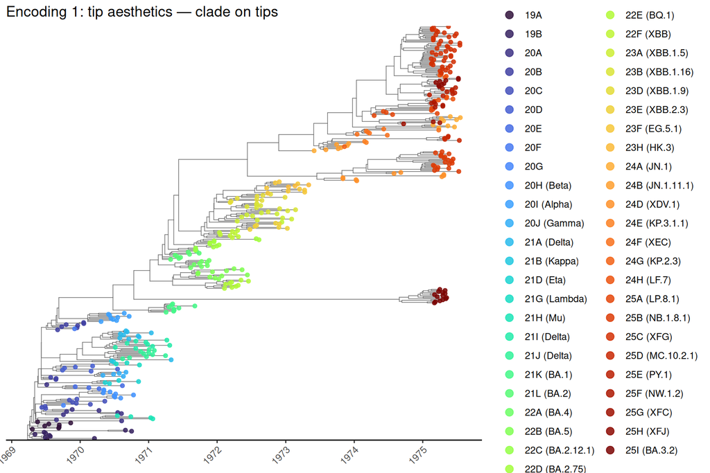

```r
p1 <- p_base +
  geom_tippoint(aes(color = Nextstrain_clade), size = 1.4, alpha = 0.85) +
  scale_color_viridis_d(option = "turbo", name = "Clade") +
  guides(color = guide_legend(override.aes = list(size = 3),
                              ncol = 2)) +
  ggtitle("Encoding 1: tip aesthetics — clade on tips")

p1
```

**Why two scales need `ggnewscale`.** A single ggplot can only have *one* color scale at a time. To put clade on big tips and region on small tips, you must reset the scale stack between the two layers:

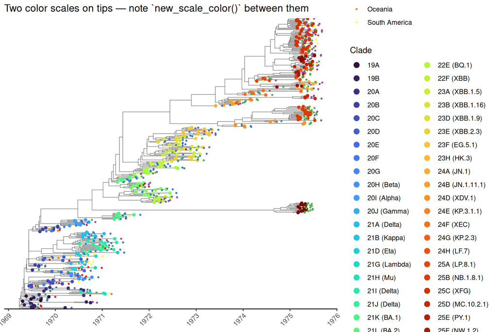

```r
p2 <- p_base +
  geom_tippoint(aes(color = Nextstrain_clade), size = 1.4) +
  scale_color_viridis_d(option = "turbo", name = "Clade") +
  guides(color = guide_legend(override.aes = list(size = 3), ncol = 2)) +
  new_scale_color() +
  geom_tippoint(aes(color = region), size = 0.6,
                position = position_nudge(x = 50)) +
  scale_color_brewer(palette = "Set1", name = "Region") +
  ggtitle("Two color scales on tips — note `new_scale_color()` between them")

p2
```

Forget `new_scale_color()` and both layers will fight over a single scale, mapping the *union* of `Nextstrain_clade` and `region` to one palette. The plot will draw, the colors will be wrong, and ggplot will not warn you.

## 3b. Branch aesthetics — ancestral state along the tree

Tips show where lineages *ended up*. Branches show *evolutionary history* — far more informative for variant emergence.

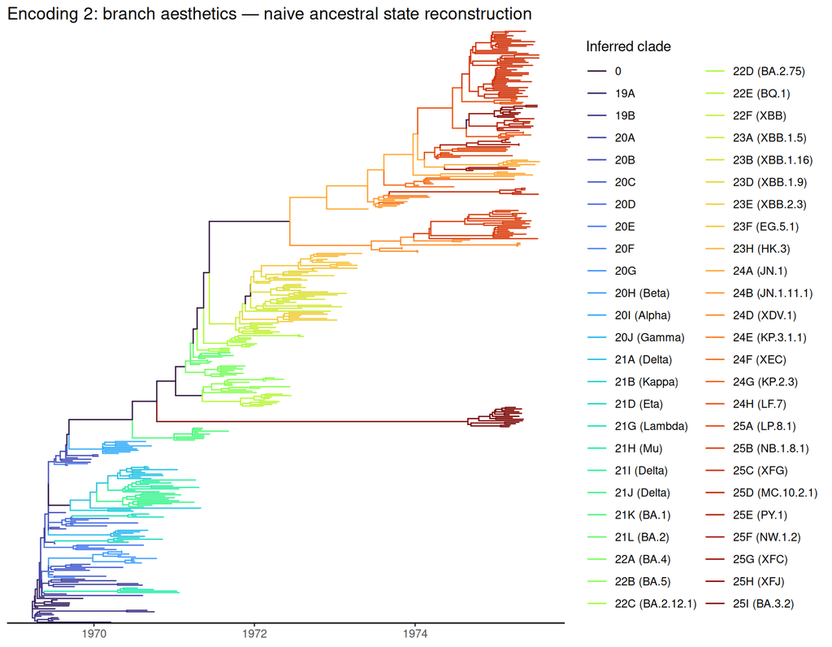

```r
# `ape::ace` requires a rooted, fully dichotomous tree. The Nextstrain
# build occasionally has polytomies — resolve them with multi2di first.
tree_d <- ape::multi2di(tree)

clade_states <- factor(meta$Nextstrain_clade[match(tree_d$tip.label, meta$strain)])
asr <- ape::ace(clade_states, tree_d, type = "discrete", model = "ER")
node_states <- apply(asr$lik.anc, 1, function(x) levels(clade_states)[which.max(x)])
all_states <- c(as.character(clade_states), node_states)

td2 <- groupOTU(tree_d, split(seq_along(all_states), all_states))

p3 <- ggtree(td2, aes(color = group), mrsd = mrsd_value,
             as.Date = TRUE, size = 0.45) +
  scale_color_viridis_d(option = "turbo", name = "Inferred clade") +
  theme_tree2() +
  guides(color = guide_legend(ncol = 2)) +
  ggtitle("Encoding 2: branch aesthetics — naive ancestral state reconstruction")

p3
```

> **Critical-thinking hazard.** ML ancestral state reconstruction with the equal-rates (ER) model ignores sampling bias and assumes time-reversibility. SARS-CoV-2 sampling is wildly biased (UK and USA dominate). Naive ASR systematically over-estimates transitions out of well-sampled regions. Useful as an illustration; *not* a basis for epidemiological claims. Read **Morel et al. 2021, MBE 38:1777** before you trust any branch-color figure.

## 3c. Heatmap matrix — `gheatmap`

When the metadata is wide and binary (presence/absence of many mutations), `gheatmap` paints a matrix beside the tree, one row per tip, one column per variable.

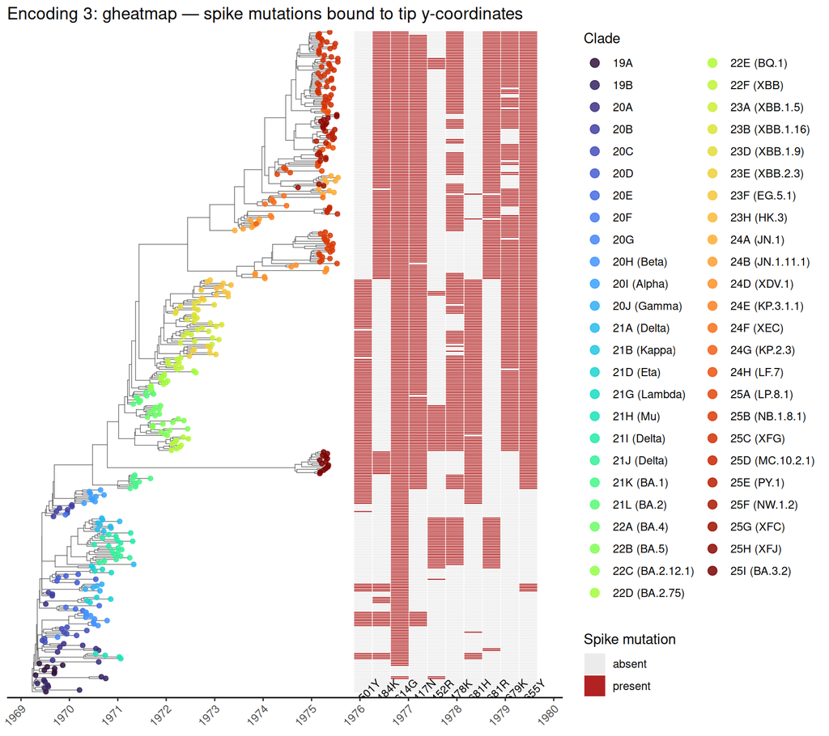

```r
key_muts <- c("S:N501Y", "S:E484K", "S:D614G", "S:K417N", "S:L452R",
              "S:T478K", "S:P681H", "S:P681R", "S:N679K", "S:H655Y")

mut_long <- meta %>%
  select(strain, nextclade_mutations) %>%
  separate_rows(nextclade_mutations, sep = ",") %>%
  filter(nextclade_mutations %in% key_muts) %>%
  distinct() %>%
  mutate(present = "present")

mut_matrix <- mut_long %>%
  pivot_wider(names_from = nextclade_mutations,
              values_from = present, values_fill = "absent") %>%
  tibble::column_to_rownames("strain")

# Make sure every key_mut is a column even if entirely absent
for (m in setdiff(key_muts, colnames(mut_matrix))) mut_matrix[[m]] <- "absent"
mut_matrix <- mut_matrix[, key_muts]

# Tips with no listed mutations need an "all absent" row
missing_tips <- setdiff(tree$tip.label, rownames(mut_matrix))
if (length(missing_tips) > 0) {
  add <- as.data.frame(matrix("absent", nrow = length(missing_tips),
                              ncol = ncol(mut_matrix),
                              dimnames = list(missing_tips, colnames(mut_matrix))))
  mut_matrix <- rbind(mut_matrix, add)
}

p4 <- gheatmap(p1, mut_matrix,
               offset = 50, width = 0.6,
               colnames_angle = 45,
               colnames_offset_y = -2,
               font.size = 3) +
  scale_fill_manual(values = c(present = "firebrick", absent = "grey92"),
                    name = "Spike mutation") +
  ggtitle("Encoding 3: gheatmap — spike mutations bound to tip y-coordinates")

p4
```

**Two principles.**

1. `gheatmap` aligns matrix rows to tip y-coordinates **by row name**. Don’t `arrange()` the matrix — sorting it by hand will silently misalign every row.
2. The figure makes **convergent evolution** visible: D614G appeared early and is fixed across most lineages; N501Y appears independently in Alpha (2020-I) and Omicron (BA.x, JN.1, …). You *see* it on the figure.

## 3d. Adjacent strips — `geom_facet`

When you want to bind several metadata columns of *different types* (a categorical, a continuous, a bar chart) to the same tree, use `geom_facet`. Each call adds a vertical strip aligned to tip y-coordinates.

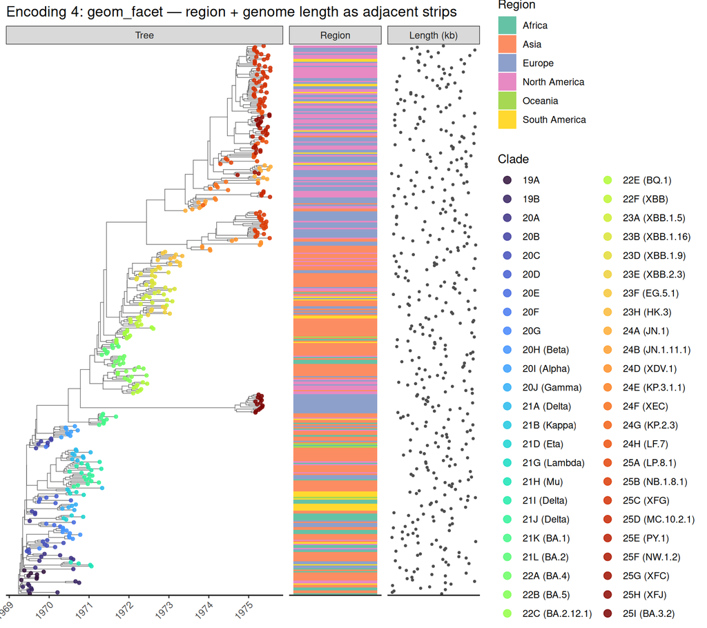

```r
# Subtle pitfall: when you attach metadata to the tree with %<+%, *only*
# include the columns the in-tree layers (e.g. tippoint color) actually
# use. Columns referenced inside geom_facet should live ONLY in the
# geom_facet `data = ...` argument. If both contexts have the same column
# (e.g. `region`), ggplot's aesthetic resolver mis-routes layer 4 of the
# assembled gtable and you get "object 'region' not found".
tip_meta <- meta %>%
  filter(strain %in% tree$tip.label) %>%
  mutate(length_kb = length / 1000)

tip_for_attach <- tip_meta %>% select(strain, Nextstrain_clade)   # for %<+%
tip_for_facet  <- tip_meta %>% mutate(label = strain)              # for geom_facet

p5_base <- ggtree(tree, mrsd = mrsd_value, as.Date = TRUE,
                  size = 0.25, color = "grey40") +
  theme_tree2() +
  scale_x_date(date_breaks = "1 year", date_labels = "%Y") +
  theme(axis.text.x = element_text(angle = 45, hjust = 1))

p5 <- p5_base %<+% tip_for_attach +
  geom_tippoint(aes(color = Nextstrain_clade),
                size = 1.2, alpha = 0.85) +
  scale_color_viridis_d(option = "turbo", name = "Clade",
                        guide = guide_legend(ncol = 2,
                                             override.aes = list(size = 3))) +
  geom_facet(panel = "Region",
             data = tip_for_facet,
             geom = geom_tile,
             mapping = aes(x = 1, fill = region),
             width = 0.6) +
  scale_fill_brewer(palette = "Set2", name = "Region") +
  geom_facet(panel = "Length (kb)",
             data = tip_for_facet,
             geom = geom_point,
             mapping = aes(x = length_kb),
             size = 0.7, color = "grey30") +
  ggtitle("Encoding 4: geom_facet — region + genome length as adjacent strips")

facet_widths(p5, c(Tree = 3, Region = 0.4, `Length (kb)` = 1.0))
```

`facet_widths()` is what controls the relative panel widths and **must be the last call** — it operates on the assembled gtable.

For very wide trees, switch to a circular layout via `ggtreeExtra::geom_fruit()`:

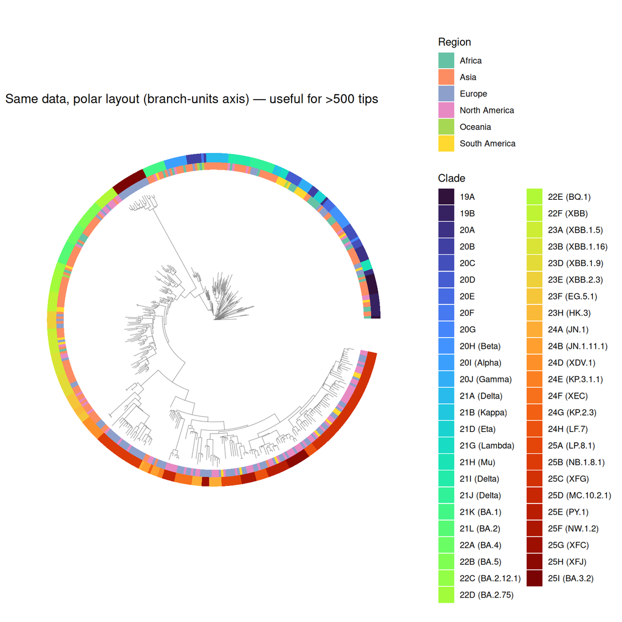

```r
# `ggtreeExtra::geom_fruit` does not currently play well with Date x-axes,
# so build the fan layout in branch-units (no mrsd) for the demo.
p_fan <- ggtree(td, layout = "fan", open.angle = 12,
                size = 0.2, color = "grey50") +
  geom_fruit(geom = geom_tile, mapping = aes(fill = region),
             offset = 0.05, width = 0.4) +
  scale_fill_brewer(palette = "Set2", name = "Region") +
  new_scale_fill() +
  geom_fruit(geom = geom_tile, mapping = aes(fill = Nextstrain_clade),
             offset = 0.05, width = 0.4) +
  scale_fill_viridis_d(option = "turbo", name = "Clade",
                       guide = guide_legend(ncol = 2)) +
  ggtitle("Same data, polar layout (branch-units axis) — useful for >500 tips")

p_fan
```

## 3e. MSA alignment — `msaplot`

When you want to link **specific sequence sites** to tree topology (e.g. “where on the tree does spike codon 501 mutate?”), put the alignment beside the tree.

This project does not ship a real spike alignment, so we generate a small synthetic one for the demo. In practice the alignment file is documented in `nextstrain_howto.md` §7 and lives at `data/spike_RBD_aligned.fasta`.

[figure not shown]

```r
# Synthetic 12-tip subtree + 60-nt fake alignment for illustration only
set.seed(7)
demo_tips <- sample(tree$tip.label, 12)
demo_tree <- ape::keep.tip(tree, demo_tips)

# Random 60-nt alignment with a few "mutated" columns to mimic real signal
nt_alphabet <- c("A", "C", "G", "T")
n_sites <- 60
ref <- sample(nt_alphabet, n_sites, replace = TRUE)

demo_aln <- vapply(demo_tips, function(tip) {
  s <- ref
  # Each tip has 0-3 random differences
  k <- sample(0:3, 1)
  if (k > 0) {
    pos <- sample(seq_len(n_sites), k)
    s[pos] <- vapply(s[pos], function(x) sample(setdiff(nt_alphabet, x), 1), character(1))
  }
  paste(s, collapse = "")
}, character(1))

aln_dss <- DNAStringSet(demo_aln); names(aln_dss) <- demo_tips
fa_path <- tempfile(fileext = ".fasta")
writeXStringSet(aln_dss, fa_path)

p_demo_base <- ggtree(demo_tree) + geom_tiplab(size = 2.8, align = TRUE)

msaplot(p_demo_base, fasta = fa_path,
        offset = 0.3, width = 1.5,
        color = c(A = "#5cb85c", C = "#5bc0de",
                  G = "#f0ad4e", T = "#d9534f", "-" = "white")) +
  ggtitle("Encoding 5: msaplot — alignment columns as cells, real example uses RBD window")
```

In a real run with `data/spike_RBD_aligned.fasta`, restrict `window = c(1390, 1620)` (or whatever the RBD nt range is for your reference) — full-genome alignments swamp the figure. Pair with branch-color-by-clade and the Omicron “wall of mutations” pattern at specific RBD positions becomes visually obvious.

## 3f. Geographic projection

Two complementary approaches:

**Side-by-side tree + map.** Country-level fill on a world map, joined to dominant-clade-per-country.

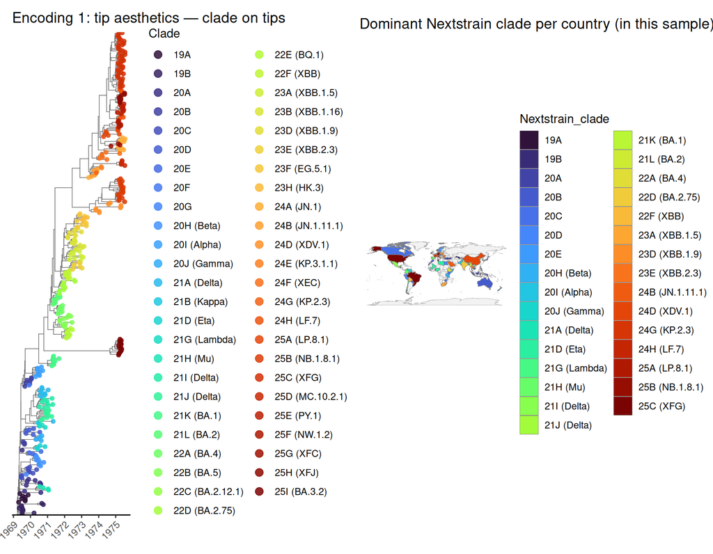

```r
world <- map_data("world")

country_clade <- meta %>%
  count(country, Nextstrain_clade) %>%
  group_by(country) %>%
  slice_max(n, n = 1, with_ties = FALSE) %>%
  ungroup()

p_map <- ggplot() +
  geom_polygon(data = world,
               aes(long, lat, group = group),
               fill = "grey95", color = "grey60", linewidth = 0.1) +
  geom_polygon(data = world %>%
                 inner_join(country_clade, by = c("region" = "country")),
               aes(long, lat, group = group, fill = Nextstrain_clade),
               color = "grey50", linewidth = 0.15) +
  scale_fill_viridis_d(option = "turbo",
                       guide = guide_legend(ncol = 2)) +
  coord_quickmap() + theme_void() +
  ggtitle("Dominant Nextstrain clade per country (in this sample)")

(p1 | p_map) + plot_layout(widths = c(1, 1.3))
```

**Tip-to-coordinate connectors** via `phytools::phylo.to.map`:

```r
suppressPackageStartupMessages(library(phytools))

coords <- meta %>%
  select(strain, latitude, longitude) %>%
  filter(strain %in% tree$tip.label,
         !is.na(latitude), !is.na(longitude)) %>%
  tibble::column_to_rownames("strain") %>%
  as.matrix()

common <- intersect(rownames(coords), tree$tip.label)
tree_geo <- ape::keep.tip(tree, common)
coords <- coords[tree_geo$tip.label, c("latitude", "longitude")]

obj <- phylo.to.map(tree_geo, coords, plot = FALSE)
plot(obj, direction = "rightwards", colors = "darkblue",
     cex.points = 0.4, ftype = "off", lwd = 0.25)
```

```
"phylo.to.map" direction is "downwards" but plot direction has been given as "rightwards".
Re-optimizing object....
```

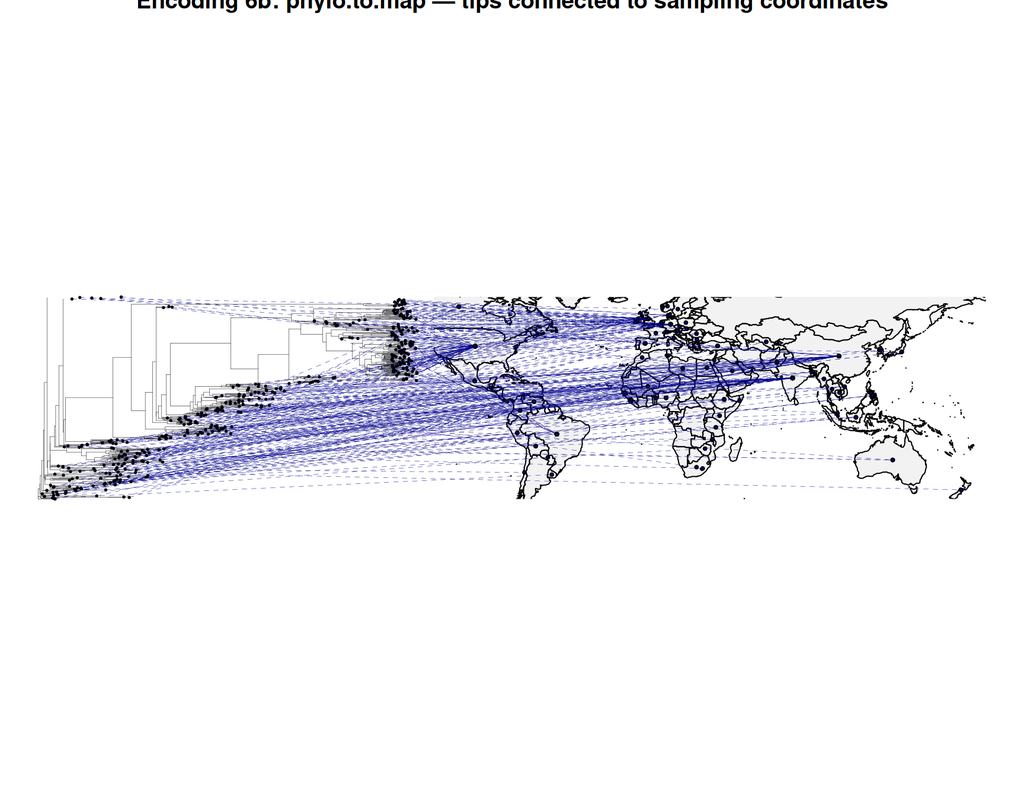

```r
title("Encoding 6b: phylo.to.map — tips connected to sampling coordinates")
```

> **Critical-thinking hazard.** Geographic visualizations are seductive but easily misleading. “Country of sampling” is not “country of infection origin.” Dense sampling in a few countries (UK, USA, Denmark for SARS-CoV-2) creates apparent geographic structure that is actually sampling bias. Compute **sequences per country relative to reported cases per country** before drawing geographic conclusions.

# 4. Pitfalls — visual quick-reference

A short list of failure modes to recognize on sight:

| Symptom | Cause | Fix |
| --- | --- | --- |
| Tree x-axis labelled in years but everything pre-dates 1900 | Branches in subs/site, not time | Time-calibrate first; check `max(node.depth.edgelength(tree))` |
| Heatmap rows misaligned with tips after `arrange()` | `gheatmap` uses row names, not row order | Don’t sort the matrix manually |
| Two color scales bleed into one weird palette | Forgot `new_scale_color()` / `new_scale_fill()` | Insert reset between layers that share an aesthetic |
| `facet_widths()` does nothing or errors | Called before assembling the gtable | `facet_widths()` MUST be the last call in the chain |
| After joining metadata, half the tips are NA | Strain-name encoding mismatch (`/`, `&#124;`, whitespace) | Run `setdiff(tree$tip.label, meta$strain)` before joining |
| Branch colors look ‘too clean’ for SARS-CoV-2 | Naive ASR with ER model + biased sampling | Treat as illustration only; cite Morel 2021 in any caption |

# 5. Where to go next

- **Yu G., 2022.** *Data Integration, Manipulation and Visualization of Phylogenetic Trees.* https://yulab-smu.top/treedata-book/. Chapters 7 (`gheatmap`, `msaplot`) and 10 (`geom_facet`) are the canonical reference for everything in this gallery.
- **Xu S. et al., 2022.** ggtreeExtra. *MBE* 39:msab166. Introduces `geom_fruit` and the polar layouts.
- **Hadfield et al., 2018.** Nextstrain. *Bioinformatics* 34:4121. The pipeline that produces the data this project consumes.
- **Morel et al., 2021.** Phylogenetic Analysis of SARS-CoV-2 Data Is Difficult. *MBE* 38:1777. Required reading before drawing epidemiological conclusions.